# Costarican Colon Exchange Rate Monitor"

Pablo Villamichel

1/8/2019

## The app and the data

This is simple and useful app that allows for daily monitoring the Costarican Colón exchange rate market. The available information is cumbersome to update and review on a daily basis. The source of the information is the Central Bank of Costa Rica

I order to streamline the updating of the data, all the data prior to end-of-year 2018 was dowloaded and kept in the server.

```
##        Date   Open  Close    Low   High   Mean     WA   Volume Num
##  2018-12-19 602.50 603.00 601.85 603.45 602.84 602.87 18194000 218
##  2018-12-20 604.00 604.55 601.02 605.48 604.68 604.82 14776000 177
##  2018-12-21 602.05 604.00 602.00 607.00 604.26 604.41 18736000 243
##  2018-12-24 602.00 606.40 602.00 606.50 605.71 606.06 11030000  84
##  2018-12-26 603.51 608.60 603.51 608.60 606.43 606.71  5138000  71
##  2018-12-27 605.00 608.10 600.00 610.15 609.12 609.59 14040000 140
##  2018-12-28 610.00 609.85 606.01 611.25 609.55 609.57  5278000 105
```

Then the information is updated with all the new data after End_of-year 2018. This way everytime it is run/viewed the data is updated to the latest available.

```
##        Date   Open  Close    Low   High   Mean     WA   Volume Num
##  2018-12-27 605.00 608.10 600.00 610.15 609.12 609.59 14040000 140
##  2018-12-28 610.00 609.85 606.01 611.25 609.55 609.57  5278000 105
##  2019-01-02 607.90 610.00 606.01 610.00 608.95 609.05  8850000 134
##  2019-01-03 611.00 609.20 603.00 611.00 609.11 609.11  8507000 136
##  2019-01-04 610.00 609.75 608.00 611.00 609.80 609.71 12353000 136
##  2019-01-07 608.51 610.25 608.51 611.50 610.60 610.66  4359000  90
##  2019-01-08 608.01 610.90 608.00 611.50 610.70 610.86  4540000  65
```

## Default app display

By default the output of the app will render:

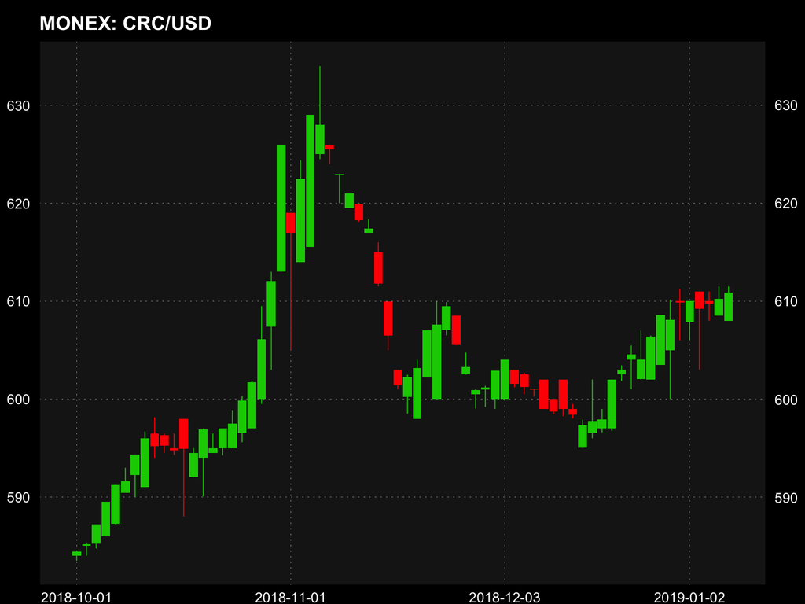

## User information

The data is updated automatically for the convenience of the user and has a nice modern financial look to it. It includes a candlestick pricing chart and has 4 parameters that can me defined:

- Initial date: The data can be displayed since December 2007. Normally these analyses are better for periods no longer than one year.
- Weighted Average: allows for the plotting of the daily weighed average that is the actual reference rate.
- Volume: Displays the bar chart with the daily volume in US$ millions.
- Number of transactions: Displays the bar chart with the daily transactions.

## App options

Changing the Initial date, while at the same time activating the WA, Volume and Number of transactions checks, the output changes:

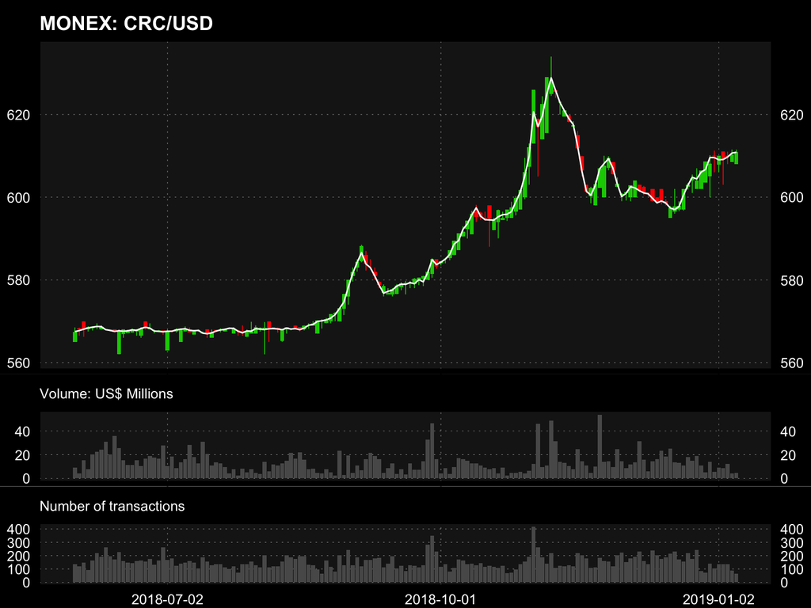